# STA 032 Midterm 1

Due April 29 midnight

# Instructions

- Upload a PDF file, named with your UC Davis email ID and midterm1 (e.g., `xjw18_midterm1.pdf`), to Gradescope (accessible through Canvas). You will give the commands to answer each question in its own code block, which will also produce output that will be automatically embedded in the output file. When asked, answer must be supported by written statements as well as any code used.
- All code used to produce your results must be shown in your PDF file (e.g., do not use `echo = FALSE` or `include = FALSE` as options anywhere). `Rmd` files do not need to be submitted, but may be requested by the TA and must be available when the assignment is submitted.
- When you want to show your result as a vector that is too long, slice the first 10 objects. When you want to show your result as a data frame, use `head()` on it. Failure to do so may lead to point deduction.
- Directly knit the Rmd file will give you an html file. Open that file in your browser and then you can print it into a PDF file.
- **No collaboration is allowed**. plagiarism will be reported.
- This is an open book exam. You can use any material from the course lecture or your own homework.

## Problem 1: combination (15 points)

Suppose a person is at Pluto’s to grab a salad. She gets a salad with 4 toppings. She can choose the toppings from 7 vegetables, 4 fruits and 3 proteins

1. How many ways can she pick 4 vegetables toppings?

2. How many ways can she pick exactly 1 protein, 2 fruits and 1 vegetable?

3. Among all possible choices, how much proportion will have equal number of vegetables and fruits? (Hint: How many protein can she pick?)

## Problem 2: Calculate the “robust” sample statistics. (20 points)

1. What is the definition of outliers in our lecture note? Why the sample mean and sample standard deviation is sensitive to extreme outliers?

2. Here is the data.

```r
# Don't change anything here
set.seed(1)
a2 = rcauchy(100, scale = 1)
```

You have already answered the outlier definition in part 1, now write R code to report the **how many** outliers in the dataset.

3. Write the code to calculate the sample mean and sample deviation for after removing the outliers. You are not allowed to use `mean()` and `sd()` in this problem, but you can use them to check the result is correct.

## Problem 3: COVID-19 data analysis (65+2 points)

We will work with COVID data downloaded from the New York Times. The dataset consists of COVID-19 cases and deaths in each US state of the COVID epidemic.

```r
# Don't change anything here
# You need internet access to download the data.

# load COVID state-level data from NYT
cv_states <- as.data.frame(read.csv("https://raw.githubusercontent.com/nytimes/covid-19-data/master/us-states.csv"))
# load state population data
state_pops <- as.data.frame(read.csv("https://raw.githubusercontent.com/COVID19Tracking/associated-data/master/us_census_data/us_census_2018_population_estimates_states.csv"))
state_pops$abb <- state_pops$state
state_pops$state <- state_pops$state_name
state_pops$state_name <- NULL
# merge the data
cv_states <- merge(cv_states, state_pops, by="state")
# change the date into date type
cv_states$date <- as.Date(cv_states$date, format="%Y-%m-%d")
# Add variables for new cases, new_cases, and new deaths, new_deaths
# Compute the 7-day rolling averages using filter() function
# use groups to do the calculation for each group.
cv_states <- cv_states %>% group_by(state) %>%
  arrange(date) %>%
  mutate(new_cases = cases - lag(cases),
         new_deaths = deaths - lag(deaths)) %>%
  mutate(avg_new_cases = stats::filter(new_cases, rep(1/7,7), sides = 1),
         avg_new_deaths = stats::filter(new_deaths, rep(1/7,7), sides = 1)) %>%
  ungroup() %>% select(-fips, -geo_id)
```

1. Inspect the dimensions and head of the data. (5 points)

And then use R function to check the structure of each variable.

```r
dim(cv_states)
```

```
[1] 58094    11
```

```r
head(cv_states)
```

```
# A tibble: 6 x 11
  state    date       cases deaths popul~1 pop_d~2 abb   new_c~3 new_d~4 avg_n~5
  <chr>    <date>     <int>  <int>   <int>   <dbl> <chr>   <int>   <int>   <dbl>
1 Washing~ 2020-01-21     1      0  7.54e6    113. WA         NA      NA      NA
2 Washing~ 2020-01-22     1      0  7.54e6    113. WA          0       0      NA
3 Washing~ 2020-01-23     1      0  7.54e6    113. WA          0       0      NA
4 Illinois 2020-01-24     1      0  1.27e7    230. IL         NA      NA      NA
5 Washing~ 2020-01-24     1      0  7.54e6    113. WA          0       0      NA
6 Califor~ 2020-01-25     1      0  3.96e7    254. CA         NA      NA      NA
# ... with 1 more variable: avg_new_deaths <dbl>, and abbreviated variable
#   names 1: population, 2: pop_density, 3: new_cases, 4: new_deaths,
#   5: avg_new_cases
```

```r
glimpse(cv_states)
```

```
Rows: 58,094
Columns: 11
$ state          <chr> "Washington", "Washington", "Washington", "Illinois", "~
$ date           <date> 2020-01-21, 2020-01-22, 2020-01-23, 2020-01-24, 2020-0~
$ cases          <int> 1, 1, 1, 1, 1, 1, 1, 1, 1, 2, 1, 1, 1, 2, 1, 1, 1, 2, 1~
$ deaths         <int> 0, 0, 0, 0, 0, 0, 0, 0, 0, 0, 0, 0, 0, 0, 0, 0, 0, 0, 0~
$ population     <int> 7535591, 7535591, 7535591, 12741080, 7535591, 39557045,~
$ pop_density    <dbl> 113.39723, 113.39723, 113.39723, 229.51116, 113.39723, ~
$ abb            <chr> "WA", "WA", "WA", "IL", "WA", "CA", "IL", "WA", "AZ", "~
$ new_cases      <int> NA, 0, 0, NA, 0, NA, 0, 0, NA, 1, 0, 0, 0, 0, 0, 0, 0, ~
$ new_deaths     <int> NA, 0, 0, NA, 0, NA, 0, 0, NA, 0, 0, 0, 0, 0, 0, 0, 0, ~
$ avg_new_cases  <dbl> NA, NA, NA, NA, NA, NA, NA, NA, NA, NA, NA, NA, NA, NA,~
$ avg_new_deaths <dbl> NA, NA, NA, NA, NA, NA, NA, NA, NA, NA, NA, NA, NA, NA,~
```

2. Format the data. (10 points)

- Make state into a factor variable
- Order the data first by state, second by date
- Inspect the summary for each variable. (Hint: `summary`)
- What is the date range? The range of cases?

```r
cv_states = cv_states %>%
  mutate(state = factor(state)) %>%
  arrange(state, date)

summary(cv_states)
```

```
           state            date                cases              deaths
 Washington   : 1158   Min.   :2020-01-21   Min.   :       1   Min.   :     0
 Illinois     : 1155   1st Qu.:2020-12-06   1st Qu.:  112125   1st Qu.:  1598
 California   : 1154   Median :2021-09-11   Median :  418120   Median :  5901
 Arizona      : 1153   Mean   :2021-09-10   Mean   :  947941   Mean   : 12553
 Massachusetts: 1147   3rd Qu.:2022-06-17   3rd Qu.: 1134318   3rd Qu.: 15952
 Wisconsin    : 1143   Max.   :2023-03-23   Max.   :12169158   Max.   :104277
 (Other)      :51184
   population        pop_density            abb              new_cases
 Min.   :  577737   Min.   :    1.292   Length:58094       Min.   :-40527
 1st Qu.: 1805832   1st Qu.:   43.659   Class :character   1st Qu.:     1
 Median : 4468402   Median :  107.860   Mode  :character   Median :   375
 Mean   : 6397965   Mean   :  423.031                      Mean   :  1788
 3rd Qu.: 7535591   3rd Qu.:  229.511                      3rd Qu.:  1520
 Max.   :39557045   Max.   :11490.120                      Max.   :227972
                    NA's   :1106                           NA's   :52
   new_deaths       avg_new_cases      avg_new_deaths
 Min.   :-3770.00   Min.   : -4502.0   Min.   :-531.714
 1st Qu.:    0.00   1st Qu.:   222.7   1st Qu.:   2.286
 Median :    3.00   Median :   682.6   Median :   7.429
 Mean   :   19.55   Mean   :  1796.5   Mean   :  19.637
 3rd Qu.:   17.00   3rd Qu.:  1760.7   3rd Qu.:  20.143
 Max.   : 3732.00   Max.   :119536.1   Max.   : 978.429
 NA's   :52         NA's   :364        NA's   :364
```

```r
max(cv_states$date)- min(cv_states$date)
```

```
Time difference of 1157 days
```

```r
max(cv_states$cases)- min(cv_states$cases)
```

```
[1] 12169157
```

3. Add additional variables (10 points)

Add population-normalized (by 100,000) variables for each variable type:

- per100k = cases per 100,000 population
- newper100k= new cases per 100,000
- deathsper100k = deaths per 100,000
- newdeathsper100k = new deaths per 100,000

Add a “naive CFR” variable representing deaths * 100 / cases on each date for each state.

```r
cv_states = cv_states %>%
  mutate(per100k = cases / 100000) %>%
  mutate(newper100k = new_cases / 100000) %>%
  mutate(deathsper100k = deaths / 100000) %>%
  mutate(newdeathsper100k = new_deaths / 100000) %>%
  mutate(naive_CFR = (deaths*100/cases) )
```

Then use this code to create a `cv_states_20210428` variable to show your result:

```
cv_states_20210428 = filter(cv_states, date=="2021-04-28")
head(cv_states_20210428, 6)
```

```r
cv_states_20210428 = filter(cv_states, date=="2021-04-28")
head(cv_states_20210428, 6)
```

```
# A tibble: 6 x 16
  state   date        cases deaths popul~1 pop_d~2 abb   new_c~3 new_d~4 avg_n~5
  <fct>   <date>      <int>  <int>   <int>   <dbl> <chr>   <int>   <int>   <dbl>
1 Alabama 2021-04-28 5.27e5  10879  4.89e6   96.5  AL        376      25    388
2 Alaska  2021-04-28 6.73e4    330  7.37e5    1.29 AK        186       0    164
3 Arizona 2021-04-28 8.61e5  17282  7.17e6   63.1  AZ        603       6    710.
4 Arkans~ 2021-04-28 3.35e5   5726  3.01e6   57.9  AR        291       1    175.
5 Califo~ 2021-04-28 3.74e6  61571  3.96e7  254.   CA       1754      67   1879.
6 Colora~ 2021-04-28 5.09e5   6406  5.70e6   55.0  CO        822       4   1662.
# ... with 6 more variables: avg_new_deaths <dbl>, per100k <dbl>,
#   newper100k <dbl>, deathsper100k <dbl>, newdeathsper100k <dbl>,
#   naive_CFR <dbl>, and abbreviated variable names 1: population,
#   2: pop_density, 3: new_cases, 4: new_deaths, 5: avg_new_cases
```

4. Create a scatterplot using `ggplot` representing `pop_density` vs. various variables: per100k and newper100k for each state on 2021-04-28, using `cv_states_20210428`. Label points by `abb` and size points by `population`, color by the naive_CFR. Detailed instruction below: (16+2 points)

- Start from `cv_states_20210428`
- use `ggplot` function. What should the `aes()` include?
- use `geom_point`. What should the `aes()` include?
- use `geom_text_repel`. What should the `aes()` include?
- rescale the x and y axis by log10. Which function you should use?
- label x axis as “Population density (persons/mile^2)”, y axis as “cases per 100,000 population” and “New cases per 100,000 population”. Title with “US covid 2021-04-28 total” and “US covid 2021-04-28 new”.
- There should be 2 plots in total. 1 code chunk for a plot.
- Extra 2 point: `scale_color_distiller(palette = "PuBu", direction = 1)` To change the color. Possible palettes: BrBG, PiYG, PRGn, PuOr, RdBu, RdGy, RdYlBu, RdYlGn, Spectral, Blues, BuGn, BuPu, GnBu, Greens, Greys, Oranges, OrRd, PuBu, PuBuGn, PuRd, Purples, RdPu, Reds, YlGn, YlGnBu, YlOrBr, YlOrRd. Possible direction: 1 or -1. Choose a reasonable color set.

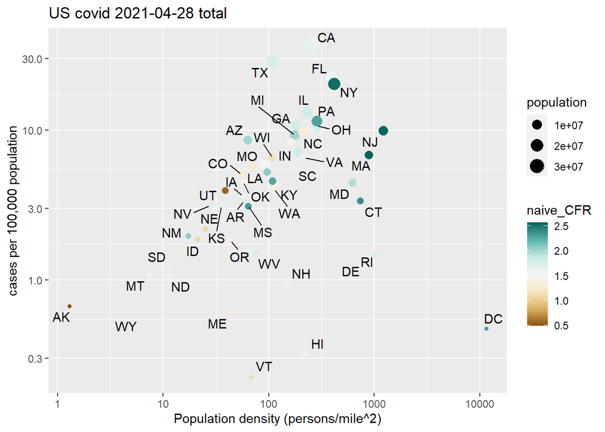

```r
cv_states_20210428 %>%
  ggplot(aes(x = pop_density, y = per100k,
             label = abb)) +
  geom_point(aes(size = population, color = naive_CFR)) +
  geom_text_repel() +
  scale_x_log10() +
  scale_y_log10() +
  xlab("Population density (persons/mile^2)") +
  ylab("cases per 100,000 population") +
  ggtitle("US covid 2021-04-28 total") +
  scale_color_distiller(palette = "BrBG", direction = 1)
```

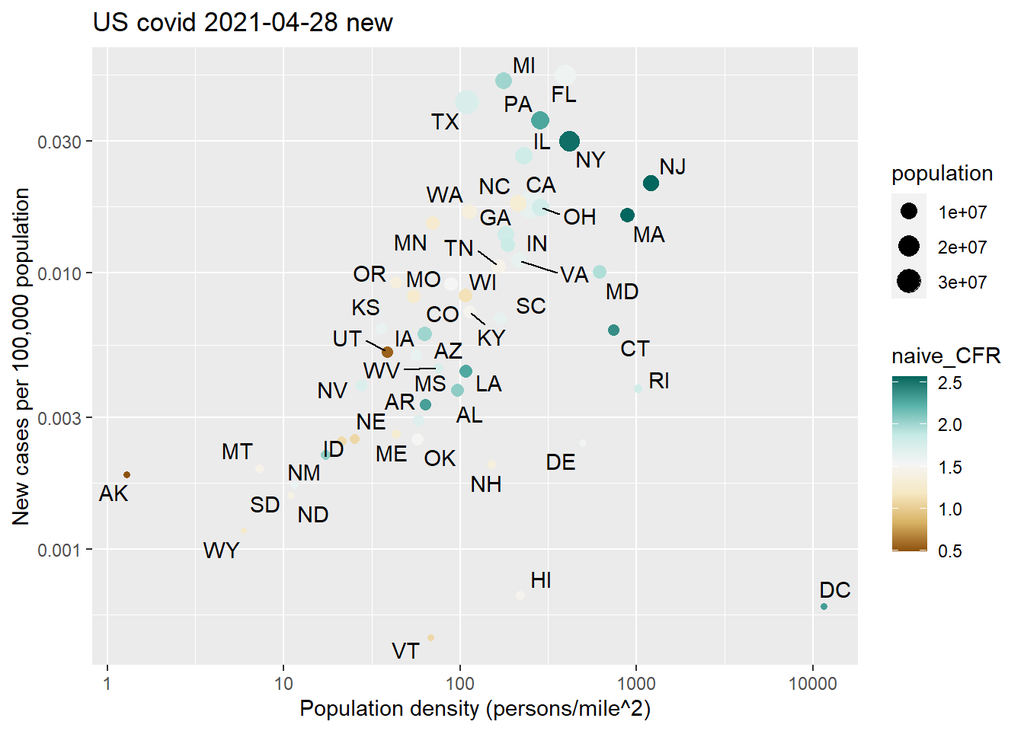

```r
cv_states_20210428 %>%
  ggplot(aes(x = pop_density, y = newper100k,
             label = abb)) +
  geom_point(aes(size = population, color = naive_CFR)) +
  geom_text_repel() +
  scale_x_log10() +
  scale_y_log10() +
  xlab("Population density (persons/mile^2)") +
  ylab("New cases per 100,000 population") +
  ggtitle("US covid 2021-04-28 new") +
  scale_color_distiller(palette = "BrBG", direction = 1)
```

5. What do you find from the last 2 plots? What can you say about CA state? (5 points)

6. Create a plot of daily cases similar to the one at the top of [this page](https://www.nytimes.com/interactive/2020/us/coronavirus-us-cases.html) for the selected states. Detailed instruction below: (14 points)

- Start from `cv_states`. Filter the `state` that contains only New York, California, Texas, Florida.
- use `ggplot` function. What should the `aes()` include? Hint: `avg_new_cases`
- use `geom_area` instead of `geom_line`.
- use `facet_wrap` to create 4 subplots with these 4 states.
- label x axis as “” (empty), y axis as “7 day average cases”. Title with “New reported cases”

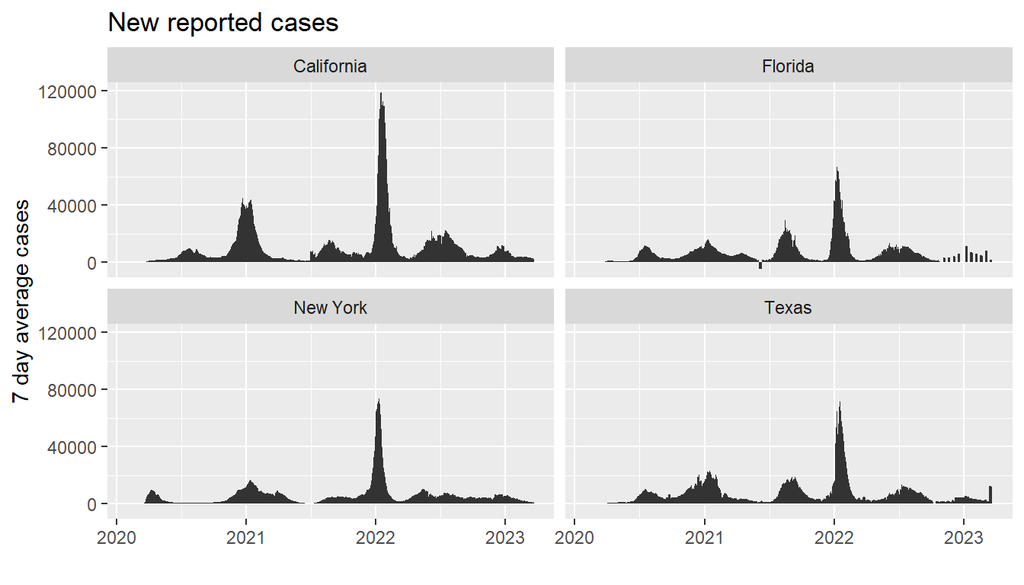

```r
cv_states %>%
  filter(state %in% c("New York", "California", "Texas","Florida")) %>%
  ggplot(aes(date, avg_new_cases)) +
  geom_area() +
  facet_wrap(~state)+
  xlab("") +
  ylab("7 day average cases") +
  ggtitle("New reported cases")
```

7. Create a map to visualize the `naive_CFR` by `state` on Jan 1, 2021 and Jan 1, 2023. Color the boundary white with `colour = "white"`. Fill the states by the `naive_CFR`. Describe the difference in the pattern of the CFR. (5 points)

```r
# Don't change this part
library(usmap)
us_states <- us_map(regions = "states")
```

Instructions:

- Filter the `cv_states` and obtain `cv_states_20210101` and `cv_states_20230101`.
- The `us_states` include the data you need to generate a US map. You need to join the `us_states` with `cv_states_20210101` to obtain `temp_1` and then join the `us_states` with `cv_states_20230101` to obtain `temp_2`.

> Hint: `inner_join(dataset1, dataset2, by = c("a" = "b"))` To join by different variables on `dataset1` and `dataset2`, use a named vector. For example, `by = c("a" = "b")` will match `dataset1$a` to `dataset2$b`.
- Use `bind_rows(list(`2021`= temp_1,`2023`= temp_2), .id = "Year")` to concat `temp_1` and `temp_2` into `data_P7`. Why we don’t use `rbind` here?
- Start from `data_P7` and pipe into a `ggplot()`. What should the `aes` be?

> Hint: `geom_polygon()` understands the following aesthetics (required aesthetics are in bold): **x**, **y**, colour, fill. What should we use to draw the map? What should them mapped to? Which one should not in aes?
- Use `geom_polygon(aes(group = group), colour = "White") + coord_equal() + ...` to generate the map.
- `facet_wrap`
- `scale_fill_distiller(palette = "PuBu", direction = 1)` To change the fill color. Possible palettes: Blues, BuGn, BuPu, GnBu, Greens, Greys, Oranges, OrRd, PuBu, PuBuGn, PuRd, Purples, RdPu, Reds, YlGn, YlGnBu, YlOrBr, YlOrRd. Possible direction: 1 or -1. Choose a reasonable color set.
- `usmap:::theme_map()+ theme(legend.position="bottom")` to change the theme.

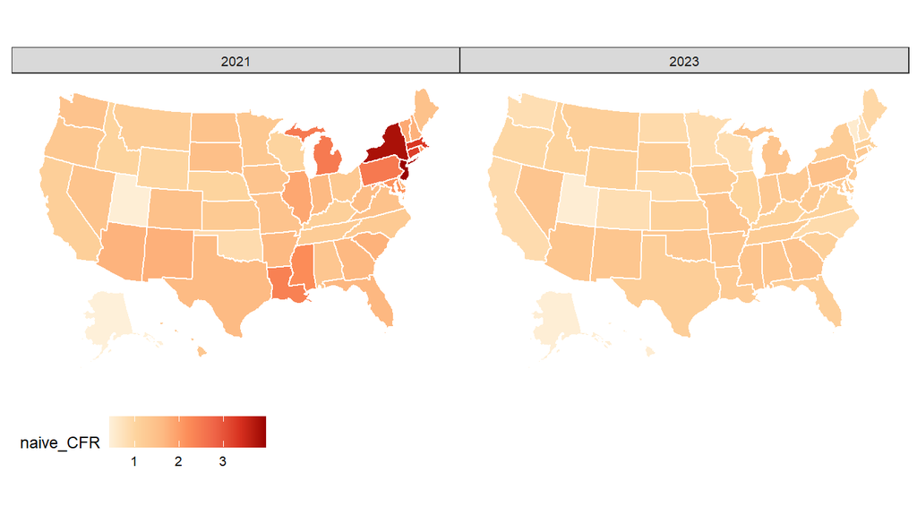

```r
cv_states_20210101 = filter(cv_states, date=="2021-01-01")
cv_states_20230101 = filter(cv_states, date=="2023-01-01")

temp_1 = inner_join(us_states,cv_states_20210101,
           by = c("abbr"="abb"))

temp_2 = inner_join(us_states,cv_states_20230101,
           by = c("abbr"="abb"))

data_P7 = bind_rows(list(`2021` = temp_1, `2023` = temp_2), .id = "Year")

data_P7 %>%
  ggplot(aes(x=x, y=y, fill=naive_CFR)) +
  geom_polygon(aes(group = group), colour = "White") +
  coord_equal() +
  facet_wrap(~Year) +
  scale_fill_distiller(palette = "OrRd",direction = 1) +
  usmap:::theme_map() + theme(legend.position="bottom")
```